# Coursework Report

*N* removed NAs: 3

*N* removed <18: 10

*N* total clean: 134

| Group | *N* | *M*<sub>age</sub> | *M*<sub>rating</sub> |
| --- | --- | --- | --- |
| Control | 70 | 21.5 | 6.55 |
| Experim | 64 | 20.7 | 4.95 |

**Main analysis results**

*t*(132) = 11, *p* < .001

# Coursework Report

Analysing Data, Spring 2020

# Methods

## Participants

*Table 1 - Participant descriptives by condition*

| Condition | *n* | *mean*<sub>Age</sub> | *SD*<sub>age</sub> | *Min*<sub>age</sub> | *Max*<sub>age</sub> |
| --- | --- | --- | --- | --- | --- |
| White | 70 | 21.5 | 2.41 | 18 | 29 |
| Red | 64 | 20.7 | 1.68 | 18 | 24 |

## Design

In this study we aimed to investigate whether perceived attractiveness was influenced by colour. The study is a replication of Elliot et al (2010) and aims to establish whether the findings are replicable. Participants where allocated to either the control or the experimental condition. If they were placed in the control condition, they were shown a picture of a man on a white border. While participants in the experimental condition were shown a picture of a man on a red border. Participants were then asked to respond to three questions on a rating scale of 1 to 9. The three question were as follows : how attractive do you think this person is ?, how pleasant is this person to look at ? and if I was to meet this person face to face, I would think this person was attractive ? The mean response of these three questions where calculated to provide a composite score of attractiveness. Using the t-test we then tested whether mean attractiveness differs when you by view a picture of a man placed on either a red or a white border.

# Results

Participants responses to the three questions were averaged in order to create a composite score of attractiveness. There was a higher mean rating across all three question when viewing the man on a white border, in comparison to the red border. The mean score across the three question and the mean composite score are shown below, grouped by condition.

*Table 2 - Summary of Mean attractvness score by condition*

| Condition | Question 1 Mean | Question 2 Mean | Question 3 Mean | Mean attractvness score |
| --- | --- | --- | --- | --- |
| White | 6.84 | 6.47 | 6.34 | 6.55 |
| Red | 4.84 | 5.09 | 4.92 | 4.95 |

The mean attractiveness rating was found to be higher in the control condition (white) then in the experimental condition. This is shown in fiqure 1 below:

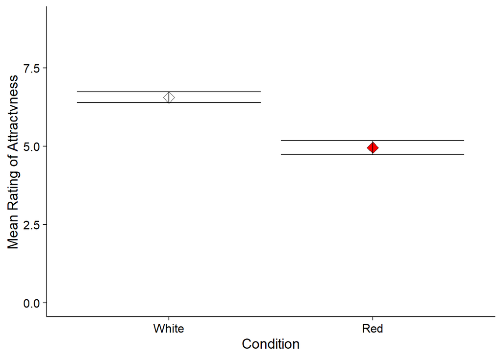

In order to establish whether there is a difference in mean perceived attractiveness between viewing the man in a red border or a white border an independent t test was conducted. Results showed that the mean attractiveness score in the control condition was significantly higher than in the experimental condition (*M*~diff = 1.6, 95% CI [1.31, 1.89], *t* (132) = 11, *p* = < .001). This suggests that participants perceive the mean attractiveness as higher when viewing on a white border then when the picture was presented on a red border.

# Discussion

Results showed there was a significant difference in the perceived attractiveness ratings between participants who saw the man on a white border in comparison to a red border. An opposite effect of that found by Elliot et al (2010) in which they found participants rated the man significantly more attractive if they saw a red border in comparison to a white border.

One potential reason for this finding could be the large difference in sample size, with Elliot et al (2010) only using a relatively small sample of 21 female undergraduates in comparison to our sample of 134 participants. The sample used in our study can therefore be seen as more valid and likely more representative of the wider population. In addition to this Francis (2013) found indication of publication bias in the original study by Elliot et al. (2010) with evidence that the small sample had low statistical power and it is unlikely that the null hypothesis would be rejected in all cases. In addition to this, other replications of the original study fail to replicate the same finding such as the study by Hesslinger, Goldbach, & Carbon (2015) which found that when using a sample of 89 participants that they gave similar ratings and showed no significant difference between the perceived attractiveness rating in the red and white conditions. These findings however still do not line up with my replication which found a significant difference with white being rated as more attractive. However, it should also be noted that there are a broad range of studies that do support the findings. Elliot & Maier (2013) replicated experiment three from the original study Elliot et al (2010) using a larger sample of 89 students and found that when comparing both red and grey back that the men in the red condition where rated as more attractive then in the grey condition, a replication of the original result.

Furthermore as recognised in the study by Hesslinger et al (2015) the original study by Elliot et al (2010) can be seen as holding at least a degree of ecological validity. Throughout the range of experiments they used participants from a range of cultures allowing the results to be applied across cultures. As well as this they applied the theory to different contrast colours and used conditions in which they changed the colour of the t shirt and the background. Consistent results were found across all of the experiments. Using two different medians for colour change is not something that I can comment on in my experiment as I only implemented the change in background and in order to comment further would need to replicate addition experiments of Elliot et al (2010). Moreover, I am also unable to comment on the extent the findings of the colour red being rated as less attractive would stand if I was to use different contrast colours such as green a grey, another possibility for future experiments.

A limitation of both the original study by Elliot et al (2010) and my subsequent replication is the use a picture of only one male who may not be representative of the wider population. Therefore in future experiments additional picture of men could be presented to woman for them to rate in order to give insight into whether this effect is a common occurrence across all men. This method was utilised in a second experiment by Hesslinger, Goldbach, & Carbon (2015) where they found that there were some variations that could be accounted to viewing different men wearing different clothing. Therefore, by incorporating this into a further replication it would also be possible to establish whether the colour white would still have higher attractiveness ratings when applied to a range of different males as a oppose to one. To take this further the study could also be replicated in a way which is less artificial and more representative of real-life interactions as opposed to viewing images on a screen. This misses key components of real life interactions such as body language and verbal interactions that could also have an impact on attractiveness ratings in real life.

Overall, in my replication of the study by Elliot et al (2010) I was unable to replicate the same findings and instead found that participants rated the picture of the male significantly more attractive when presented on a white border then a red border. These difference in findings could be accounted for by a large difference in sample size between the original study and my replications, as well as the low statistical power of the original sample putting into question the validity (Francis, 2013). With my current replication i am unable to comment on the additional study conducted by Elliot et al (2010) and how using different contrast colours as well as changing the colour of different factors would affect the results. Further research could be conducted in this area to further investigate the effect of different colours, as well as researching focusing on using more natural procedures.

# References

Elliot, A. J., & Maier, M. A. (2013). The red-attractiveness effect, applying the ioannidis and trikalinos(2007b) test, and the broader scientific context: A reply to francis (2013). Journal of Experimental Psychology: General, 142(1), 297–300. https://doi.org/10.1037/a0029592

Elliot, A. J., Niesta Kayser, D., Greitemeyer, T., Lichtenfeld, S., Gramzow, R. H., Maier, M. A., & Liu, H. (2010). Red, Rank, and Romance in women viewing men. Journal of Experimental Psychology: General, 139(3), 399–417. https://doi.org/10.1037/a0019689

Francis, G. (2013). Comment publication bias in Red, Rank, and Romance in women viewing men, by Elliot et al. (2010). Journal of Experimental Psychology: General, 142(1), 292–296. https://doi.org/10.1037/a0027923

Hesslinger, V. M., Goldbach, L., & Carbon, C. C. (2015). Men in red: A reexamination of the red-attractiveness effect. Psychonomic Bulletin and Review, 22(4), 1142–1148. https://doi.org/10.3758/s13423-015-0866-8